# Regional Favoritism

Nighttime Lights, Leader Birthplaces, and the Geography of Political Redistribution

Ömer Furkan Çoban

Applied Econometrics Using GIS Techniques (SoSe 2026)Prof. Dr. Erkan Gören

27-08-2026

# Agenda

Section 01 / 07

## Agenda

- Introduction
- Literature
- Data Sources
- Empirical Framework
- Extension
- Conclusion

# Introduction

Section 02 / 07

## What’s Regional Favoritism?

The tendency of national leaders to direct disproportionate public resources toward their own birth region, rather than allocating them on the basis of need or national interest.

### How It’s Measured

- Compare a leader’s birth region against all other regions of the same country, in the same year
- Use satellite-recorded nighttime light intensity as a proxy for local economic activity
- Ask whether the birth region gets systematically brighter while its leader is in power

## An Example: Ivory Coast

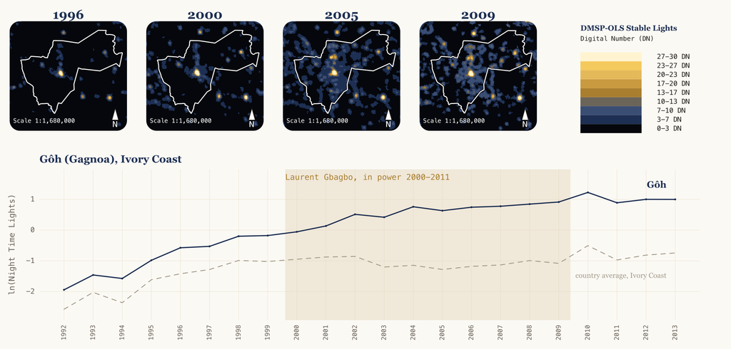

## The Paper We Replicate

### Hodler & Raschky (2014), *Quarterly Journal of Economics*

Research question

Do national leaders steer resources to the region they were born in? And if so, how far does the effect reach geographically, how long does it last, and where is it worst?

Sample

**38,427 subnational regions in 126 countries**, observed annually from **1992 to 2009**, covering the entire usable DMSP-OLS satellite nighttime light record at the time.

Empirical Strategy

The outcome is nighttime light intensity. A region is treated in the years its country’s effective leader was born there. Region and country-year fixed effects hold the comparison **within country, within year**.

Finding

Birth regions are about **4% brighter** while their leader is in office. The effect is strongest where institutions are weak and education low, and it is amplified by foreign aid and oil rents (Hodler & Raschky, 2014).

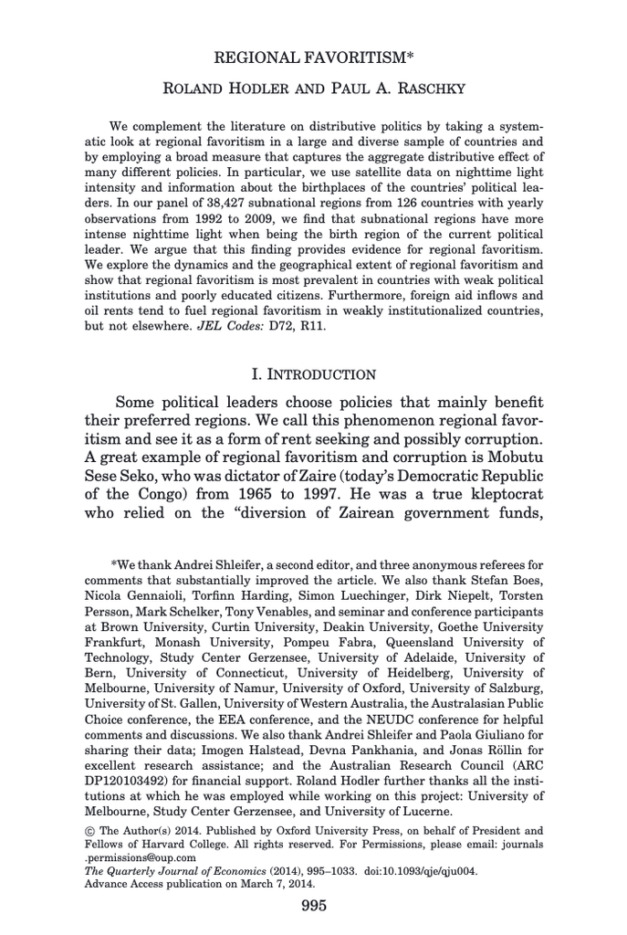

# Literature

Section 03 / 07

## Literature

Foundational

Measuring Economic Growth from Outer Space (Henderson et al., 2012)

- **Data:** Nighttime lights matched to national GDP growth, cross-country panel
- **Scope:** Validating satellite light growth as an economic-activity proxy
- **Finding:** Light growth is an **independent proxy for GDP growth** that outperforms official statistics where national accounts are weak

Distributive Politics Around the World (Golden & Min, 2013)

- **Data:** Review of the distributive-politics literature, no single dataset
- **Scope:** How political favoritism has been measured across countries
- **Finding:** Prior work relied almost entirely on **single-country spending data**, leaving systematic cross-country evidence largely absent

Related / Extensions

Does the Leader’s Ethnicity Matter? (Franck & Rainer, 2012)

- **Data:** Demographic and Health Surveys, Sub-Saharan Africa
- **Scope:** Ethnic favoritism in health and education outcomes
- **Finding:** Districts sharing the president’s ethnicity see **relative gains in education and child mortality** while that leader is in power

Birthplace Favoritism Revisited (Bora, 2025)

- **Data:** VIIRS nighttime lights, 2012-2025, matched to PLAD birthplaces and GADM boundaries
- **Scope:** Robustness of birthplace favoritism in the modern, high-frequency era
- **Finding:** Favoritism starts **immediately on taking office** and persists after leaving it, with a further premium during COVID-19 in weaker democracies

# Data

Section 04 / 07

## Data Sources: Outcome, Geography & Leaders

Source

Coverage

Used For

Outcome Variable

01

[figure not shown]

DMSP-OLS Nighttime Lights

30 arc-sec (∼1 km) · WGS84 (EPSG:4326) · geographic, unprojected

(Earth Observation Group, Payne Institute for Public Policy, Colorado School of Mines, 2013)

**Annual, 1992-2014** · 0-63 DN scale · sub-km pixels, all countries

**Dependent variable**: `log(light + 0.01)`, average pixel intensity per region-year. A high concentration of observations sits at the lower bound, hence the added constant.

Political Leaders

02

[figure not shown]

Archigos, extended with birthplaces

(Goemans et al., 2009)

Effective leader per country-year to 2004, **hand-extended by HR to 2010**. Base universe: **919 leader-spells, 172 countries**.

Defines **who was leading which country, and when**: the base list rows 3 and 4 attach a birthplace onto. Constructs `Experience` and `TotalTenure` directly; contributes no birthplace itself.

03

[figure not shown]

↓PLAD Birthplace Coordinates

(Bomprezzi et al., 2024)

Matches **799 / 919** leader-spells (**86.9%**). Zero coverage for **25 countries**.

**Primary** birthplace source for our own panel: coordinates point-in-polygon joined to GADM ADM2. **Authoritative** wherever it has an entry.

04

[figure not shown]

↓Wikidata/Wikipedia Scrape

(Wikidata, 2026)

108 missing leaders queried, 42 resolved, **33** confirmed in-country.

**Gap-fill only** where PLAD has zero coverage. Combined coverage: 799 + 33 = **832 / 919 = 90.5%**.

Geography

05

[figure not shown]

Subnational Boundaries & Settlement Points  
We use GADM 3.6

Vector polygons · WGS84 (EPSG:4326) · geographic, unprojected

(CIESIN, Columbia University, 2005) → (GADM, 2018)

Second-level administrative regions · **126 countries, 38,427 regions**. Excludes countries under **500,000** people and any territory entirely above **65°N**.

Defines HR’s regional units of observation; settlement-point shapefiles geolocate leader birthplaces to a specific region. This CIESIN product was **never publicly released** as underlying data (SEDAC serves only PDF/PNG map previews), so our own geometry substitutes **GADM 3.6**.

Population

06

[figure not shown]

Gridded Population of the World, v3 & v4

GPWv3 2.5 arc-min · GPWv4 5 arc-min · WGS84 (EPSG:4326), unprojected

(CIESIN, Columbia University and CIAT, 2005) · (CIESIN, Columbia University, 2018)

Region-year · **GPWv3** anchors 1990/1995, **GPWv4 rev.11** anchors 2000/2005/2010, bridged and interpolated to an annual panel

Builds `lnpop` (log regional population in thousands) and the per-capita light outcome `Lightpc`. HR’s Appendix A sources `Population_ict` from CIESIN “every fifth year from 1990,” which is **GPWv3**; **GPWv4 (2018)** did not exist yet at HR’s writing, so it extends the same CIESIN series past 2010. The two products’ 2000 overlap year is used to compute a **per-country bridge factor**, scaling GPWv4 onto GPWv3’s level before interpolating.

## Data Sources: Country-Level Covariates

Source

Coverage

Used For

Institutions & Human Capital

07

[figure not shown]

Political Regime Characteristics

(Marshall et al., 2010)

Country-year, 1800-2010 · rescaled **Polity2 score, 0 to 1**

Measures **executive constraints** and openness of political competition; interacted with `Leader` in **Table V**.

08

[figure not shown]

Educational Attainment Dataset

(Barro & Lee, 2013)

Country-year · 5-year intervals, **1950-2010**

**Average years of schooling** attained; a second institutional-quality proxy interacted with `Leader`.

Economic & Cultural Covariates

09

[figure not shown]

Penn World Table, GDP per Capita

(Heston et al., 2012)

Country-year, U.S. dollars

**Log GDP per capita**, the baseline economic control for national income.

10

[figure not shown]

Linguistic Fractionalization

(Alesina et al., 2003)

Country level, **time-invariant**

**Probability** two random citizens speak different languages; interacted with `Leader` as a cultural-cohesion proxy.

11

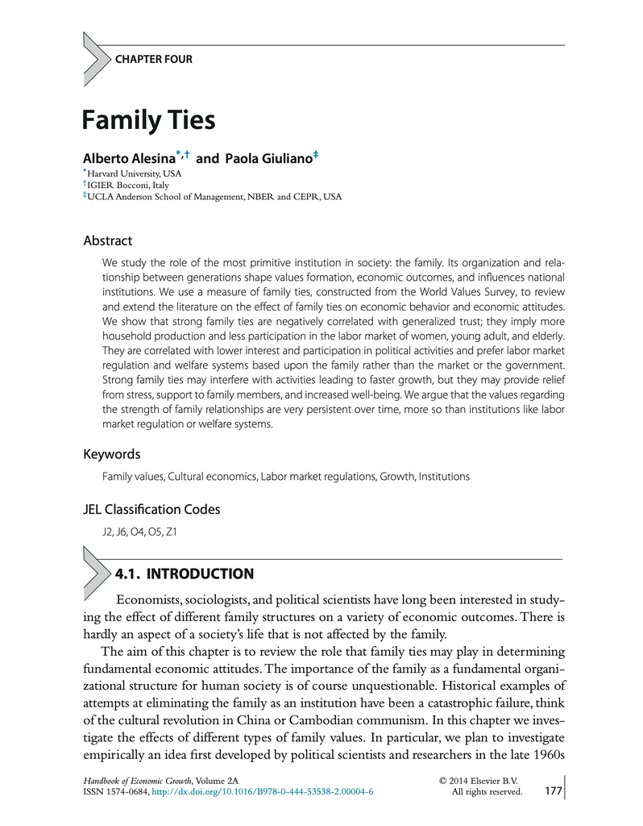

Family Ties

(Alesina & Giuliano, 2014)

Country level, **time-invariant**

Strength of family bonds from **World Values Survey** responses; interacted with `Leader` alongside fractionalization.

External Resource Flows

12

[figure not shown]

Net Official Development Assistance

(OECD, 2013)

Country-year, current U.S. dollars

**Log Official Development Assistance per capita**; interacted with `Leader` in **Table VII** to test whether aid inflows fuel favoritism.

13

[figure not shown]

Adjusted Net Savings, Oil Rents

(World Bank, 2013)

Country-year, current U.S. dollars per capita

**Log oil rents per capita**; interacted with `Leader` alongside aid in the same heterogeneity test.

Alternative Outcome (Robustness)

14

[figure not shown]

[figure not shown]

Subnational Regional GDP Data  
We use G-Econ 4.0

1 degree grid (∼111 km) · WGS84 (EPSG:4326), unprojected

(Gennaioli et al., 2014) → (Nordhaus et al., 2006)

1-degree global grid · benchmark years 1990/95/2000/05, **190 countries**, aggregated to ADM2 by point-in-polygon join

**Regional GDP per capita** for Column (8). HR’s own source, Gennaioli et al. (2014), **is not publicly available**. Reproduces the same direction and significance (**0.013** vs. HR’s published **0.021**).

## Data Sources: Descriptive Statistics

| Variables | Hodler & Raschky (2014) 126 countries · 1992-2009 Obs. | Hodler & Raschky (2014) 126 countries · 1992-2009 Mean | Hodler & Raschky (2014) 126 countries · 1992-2009 SD | Hodler & Raschky (2014) 126 countries · 1992-2009 Min | Hodler & Raschky (2014) 126 countries · 1992-2009 Max | Our Panel, HR-Exact Sample same 126 countries · 1992-2009 Obs. | Our Panel, HR-Exact Sample same 126 countries · 1992-2009 Mean | Our Panel, HR-Exact Sample same 126 countries · 1992-2009 SD | Our Panel, HR-Exact Sample same 126 countries · 1992-2009 Min | Our Panel, HR-Exact Sample same 126 countries · 1992-2009 Max |
| --- | --- | --- | --- | --- | --- | --- | --- | --- | --- | --- |
| Light<sub>ict</sub> | 690,495 | 0.050 | 2.482 | -4.605 | 4.143 | 655,659 | 0.098 | 2.456 | -4.605 | 4.143 |
| Leader<sub>ict-1</sub> | 690,495 | 0.004 | 0.060 | 0.000 | 1.000 | 613,433 | 0.004 | 0.060 | 0.000 | 1.000 |
| Polity<sub>ct-1</sub> | 684,213 | 0.789 | 0.257 | 0.000 | 1.000 | 612,746 | 0.789 | 0.258 | 0.000 | 1.000 |
|  | (2,205) | (0.670) | (0.312) |  |  | (1,922) | (0.680) | (0.307) |  |  |
| Schooling<sub>ct-1</sub> | 648,240 | 8.168 | 2.783 | 0.925 | 13.022 | 586,029 | 8.124 | 2.778 | 0.930 | 13.052 |
|  | (1,922) | (6.968) | (2.920) |  |  | (1,700) | (7.081) | (3.015) |  |  |
| NationalGDP<sub>ct-1</sub> | 683,669 | 8.868 | 1.147 | 5.080 | 10.855 | 615,481 | 8.829 | 1.178 | 5.081 | 10.855 |
|  | (2,200) | (8.212) | (1.347) |  |  | (1,946) | (8.245) | (1.356) |  |  |
| Language<sub>c</sub> | 679,119 | 0.318 | 0.281 | 0.002 | 0.923 | 647,822 | 0.313 | 0.286 | 0.002 | 0.923 |
|  | (2,161) | (0.438) | (0.298) |  |  | (2,022) | (0.442) | (0.297) |  |  |
| FamilyTies<sub>c</sub> | 551,004 | 0.096 | 0.311 | -0.851 | 0.606 | 521,800 | 0.059 | 0.365 | -0.912 | 0.572 |
|  | (1,112) | (0.041) | (0.368) |  |  | (1,021) | (-0.015) | (0.391) |  |  |
| Aid<sub>ct-1</sub> | 690,495 | 6.191 | 4.743 | -10.632 | 13.712 | 405,898 | 7.891 | 3.284 | -10.597 | 13.559 |
|  | (2,251) | (7.794) | (4.746) |  |  | (1,476) | (9.262) | (2.651) |  |  |
| Oil<sub>ct-1</sub> | 645,396 | 9.357 | 4.116 | 0.000 | 16.396 | 609,906 | 8.945 | 4.038 | 0.000 | 16.126 |
|  | (1,820) | (6.590) | (5.262) |  |  | (1,900) | (5.954) | (5.146) |  |  |

*Notes.* Descriptive statistics at the country-year level in parentheses.

Our panel restricted to HR’s own **126-country list** and their exact **1992-2009** window, ADM2 regions entirely above **65°N** dropped, matching their stated exclusion criteria exactly, with the same variables and `t−1` lag structure. Remaining gaps in Obs. reflect **real source-level coverage differences** (e.g. GPWv3/v4 vs. HR’s own CIESIN vintage), not sample-restriction bugs.

# Empirical Framework

Section 05 / 07

## Empirical Framework

$$\text{Light}_{ict} \;=\; \alpha_i \;+\; \beta_{ct} \;+\; \gamma\,\text{Leader}_{ict-1} \;+\; \varepsilon_{ict}$$

The Variables

- $\text{Light}_{ict}$ is log nighttime light intensity(`log(light + 0.01)`) for region $i$, country $c$, year $t$ .
- $\text{Leader}_{ict-1}$ is 1 if region $i$ was the effective leader’s birth region in $t-1$, 0 otherwise.

Fixed Effects, $\alpha_i$ and $\beta_{ct}$

- $\alpha_i$ absorbs everything **time-invariant** about a region.
- $\beta_{ct}$ absorbs every **national shock common to a country-year**.
- What survives is variation **within region, within country, within year**.

Coefficient of Interest, $\gamma$

- HR expect and find $\gamma > 0$: a **positive, significant $\gamma$** is read as evidence of regional favoritism.
- Standard errors are **clustered by leader**, lagged one period for consistency with $\text{Leader}_{ict-1}$ itself.

## Main Results and Robustness Tests (Table II)

|  | (1)Light<sub>ict</sub> Orig. | (1)Light<sub>ict</sub> Repl. | (2)Light<sub>ict</sub> Orig. | (2)Light<sub>ict</sub> Repl. | (3)Light<sub>ict</sub> Orig. | (3)Light<sub>ict</sub> Repl. | (4)Light<sub>ict</sub> Orig. | (4)Light<sub>ict</sub> Repl. | (5)Light<sub>ict</sub> Orig. | (5)Light<sub>ict</sub> Repl. | (6)Light0<sub>ict</sub> Orig. | (6)Light0<sub>ict</sub> Repl. | (7)Lightpc<sub>ict</sub> Orig. | (7)Lightpc<sub>ict</sub> Repl. | (8)RegionalGDP<sub>ict</sub> Orig. | (8)RegionalGDP<sub>ict</sub> Repl. |
| --- | --- | --- | --- | --- | --- | --- | --- | --- | --- | --- | --- | --- | --- | --- | --- | --- |
| Leader<sub>ict-1</sub> | 0.038*** (0.014) | 0.032** (0.015) |  |  |  |  | 0.019*** (0.010) | 0.026*** (0.010) | 0.061*** (0.010) | 0.050*** (0.008) | 0.029*** (0.013) | 0.008 (0.012) | 0.062*** (0.024) | 0.025** (0.011) | 0.021*** (0.006) | 0.013** (0.006) |
| Leader<sub>ict</sub> |  |  | 0.039*** (0.015) | 0.029* (0.016) |  |  |  |  |  |  |  |  |  |  |  |  |
| Leader<sub>ict-2</sub> |  |  |  |  | 0.041*** (0.013) | 0.040*** (0.015) |  |  |  |  |  |  |  |  |  |  |
| Light<sub>ict-1</sub> |  |  |  |  |  |  | 0.400*** (0.023) | 0.408*** (0.025) | 0.962*** (0.004) | 0.964*** (0.004) |  |  |  |  |  |  |
| Pop<sub>ict</sub> |  |  |  |  |  |  |  |  |  |  |  |  | 0.958*** (0.066) | -0.714*** (0.067) | 0.201*** (0.049) | -0.007* (0.004) |
| Number of regions | 38,427 | 38,474 | 38,427 | 38,474 | 38,427 | 38,474 | 38,427 | 38,474 | 38,427 | 38,474 | 36,591 | 37,179 | 37,475 | 38,474 | 1,207 | 6,531 |
| Observations | 690,495 | 654,254 | 690,495 | 655,234 | 689,870 | 578,100 | 652,362 | 616,760 | 652,362 | 616,760 | 619,594 | 593,814 | 673,382 | 654,254 | 14,995 | 113,110 |
| Within R<sup>2</sup> | 0.319 | 0.314 | 0.319 | 0.315 | 0.318 | 0.239 | 0.412 | 0.398 | 0.964 | 0.969 | 0.393 | 0.350 | 0.197 | 0.418 | 0.653 | 0.803 |
| Region FE | Yes | Yes | Yes | Yes | Yes | Yes | Yes | Yes | No | No | Yes | Yes | Yes | Yes | Yes | Yes |
| Country-year FE | Yes | Yes | Yes | Yes | Yes | Yes | Yes | Yes | Yes | Yes | Yes | Yes | Yes | Yes | Yes | Yes |

*Notes.* Fixed effect regressions (except for Column (5), which is standard OLS) using annual data for subnational regions between 1992 and 2009. `Lightict` is the log of average nighttime light intensity plus 0.01. `Light0ict` is the log of average nighttime light intensity (without adding a constant). `Lightpcict` is the log of nighttime light intensity per capita plus 0.01. `RegionalGDPict` is the log of regional GDP per capita. `Leaderict` is a dummy variable equal to 1 if region i is the birth region of the political leader in country c in year t, and 0 otherwise. `Popict` is the log of regional population. Standard errors are adjusted for leader clustering. ***, **, * indicate significance at the 1%, 5%, and 10% levels, respectively.

Sample restricted to HR’s exact **126-country, 1992-2009** window. Column (8) uses G-Econ 4.0, our substitute for HR’s own Gennaioli et al. (2014) source, which was never publicly released. All eight **Leader** coefficients match HR’s sign; Column (6) **loses significance** in our panel (0.008, not significant, vs. HR’s 0.029***). **Pop**’s sign flips in Columns (7)-(8), a genuine population-source difference (GPWv4 vs. HR’s CIESIN vintage), not a bug.

## Empirical Framework: Geographic Extent (Table IV)

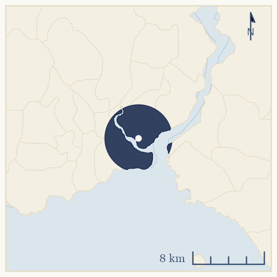

(1)Light<sub>ict</sub>

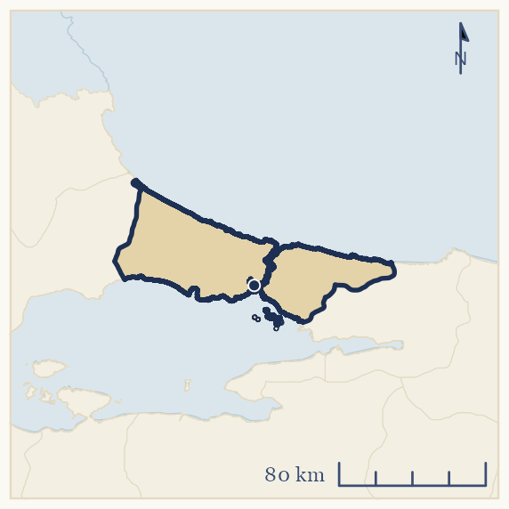

(2)Light<sub>ict</sub>

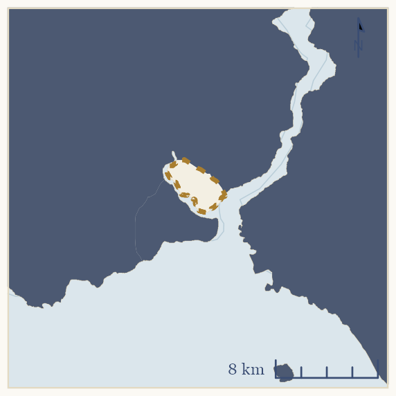

(3)Light<sub>ict</sub>

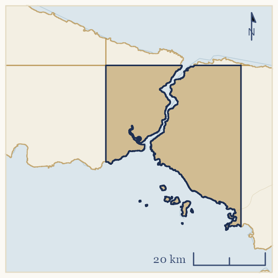

(4)Light<sub>ict</sub>

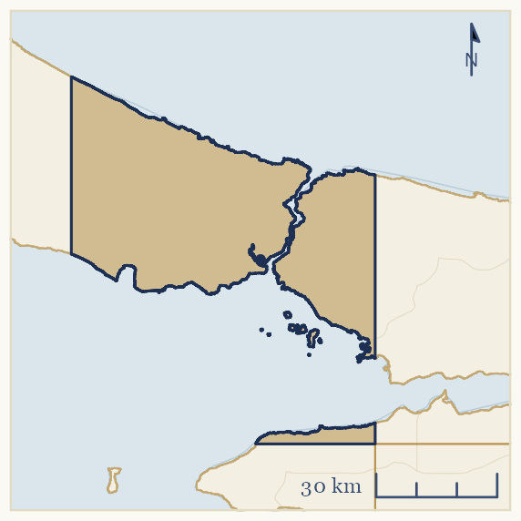

(5)Light<sub>ict</sub>

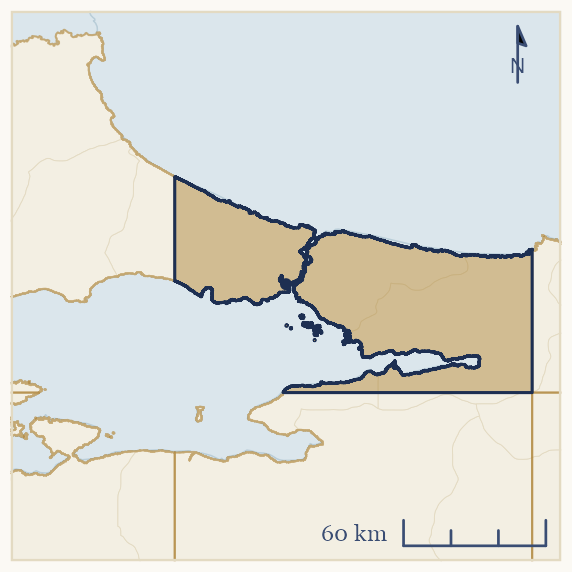

(6)Light<sub>ict</sub>

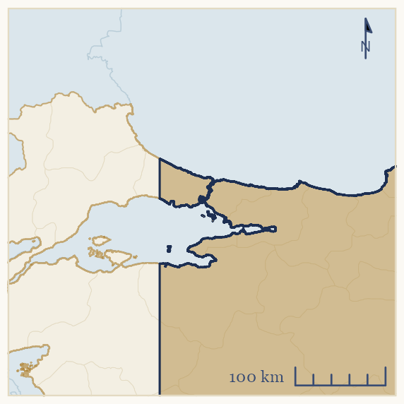

(7)Light<sub>ict</sub>

Orig.

Repl.

Orig.

Repl.

Orig.

Repl.

Orig.

Repl.

Orig.

Repl.

Orig.

Repl.

Orig.

Repl.

Leader<sub>ict-1</sub>

0.049**  
(0.024)

0.024  
(0.020)

0.026**  
(0.010)

0.017  
(0.011)

0.023**  
(0.012)

0.010  
(0.012)

0.043***  
(0.010)

0.036***  
(0.012)

0.028**  
(0.011)

0.019*  
(0.011)

0.020**  
(0.009)

-0.001  
(0.009)

0.005  
(0.009)

-0.004  
(0.008)

Units of observation

5 km circles

SN1 regions

SN1, excl. birth-SN2

50 km grid

100 km grid

200 km grid

400 km grid

Number of regions

520

718

2,242

2,408

2,220

2,408

64,204

59,891

17,242

17,393

6,101

5,545

2,110

1,993

Observations

9,134

11,522

40,157

40,936

39,761

40,936

1,048,370

988,347

280,210

286,650

101,655

91,132

35,889

32,547

Within R<sup>2</sup>

0.520

0.493

0.602

0.650

0.603

0.644

0.210

0.299

0.298

0.350

0.362

0.396

0.449

0.478

Region FE

Yes

Yes

Yes

Yes

Yes

Yes

Yes

Yes

Yes

Yes

Yes

Yes

Yes

Yes

Country-year FE

Yes

Yes

Yes

Yes

Yes

Yes

Yes

Yes

Yes

Yes

Yes

Yes

Yes

Yes

*Notes.* Fixed effect regressions using annual data for subnational regions between 1992 and 2009. The units of observation differ across columns and are indicated in their own row (see text for details). `Lightict` is the log of average nighttime light intensity plus 0.01. `Leaderict` is a dummy variable equal to 1 if region i is the birth region of the political leader in country c in year t, and 0 otherwise. Standard errors are adjusted for leader clustering. ***, **, * indicate significance at the 1%, 5%, and 10% levels, respectively.

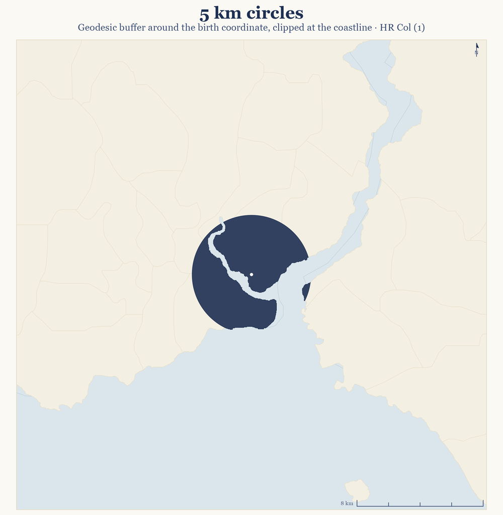

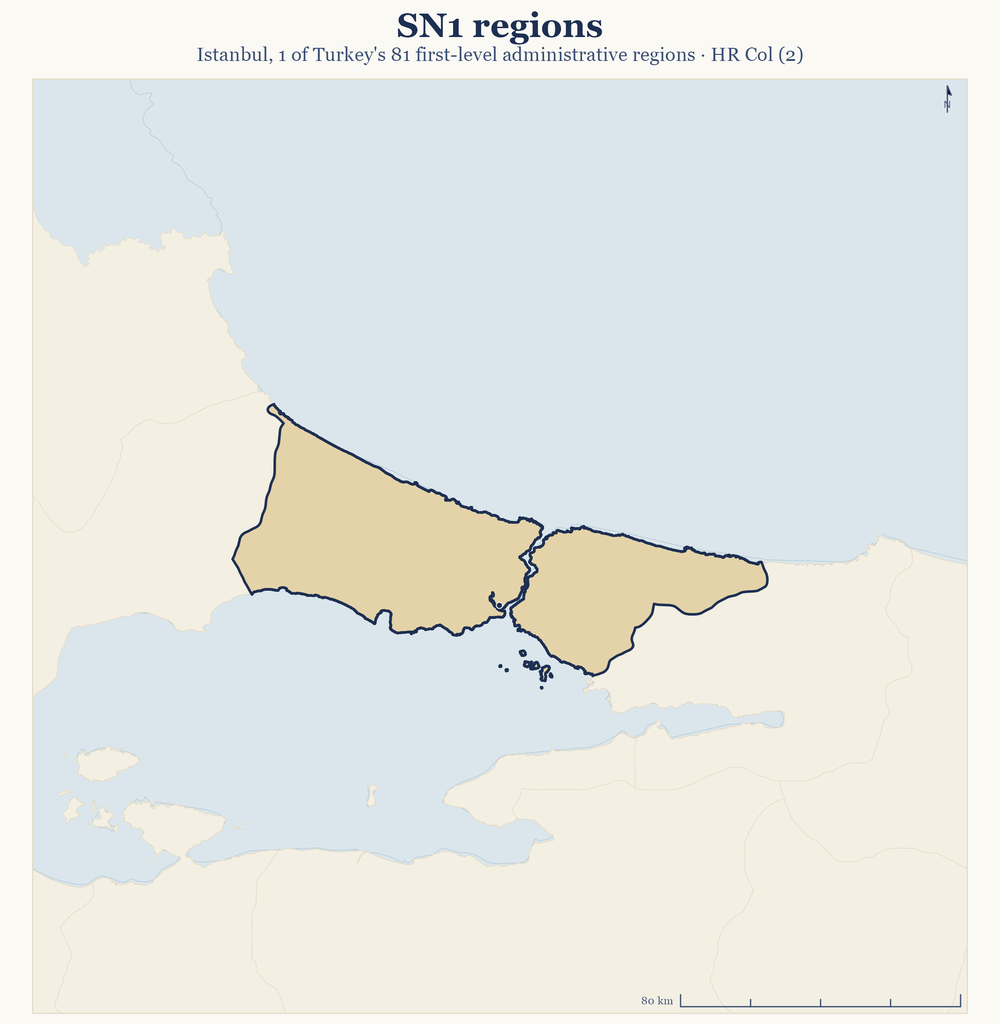

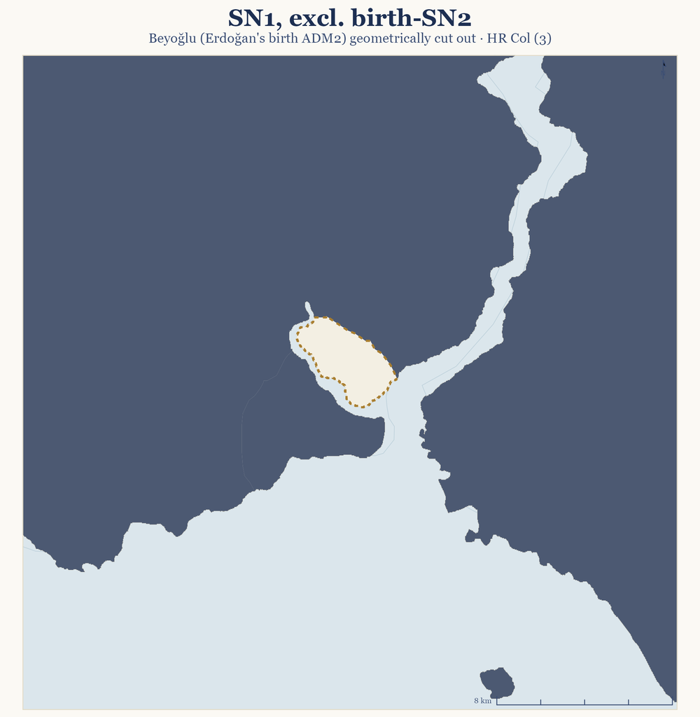

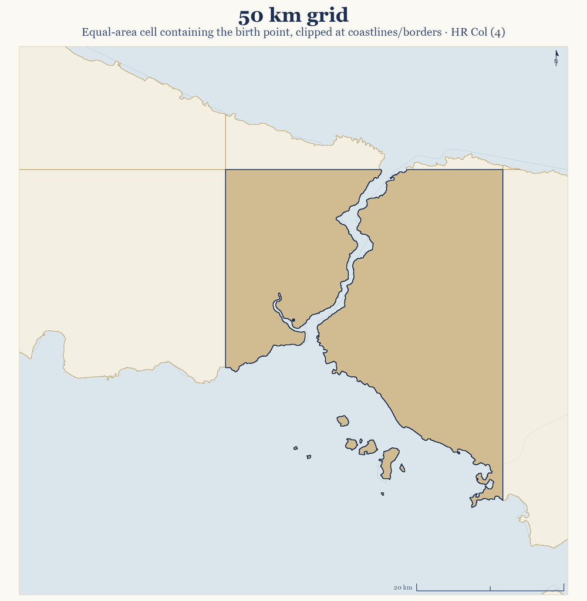

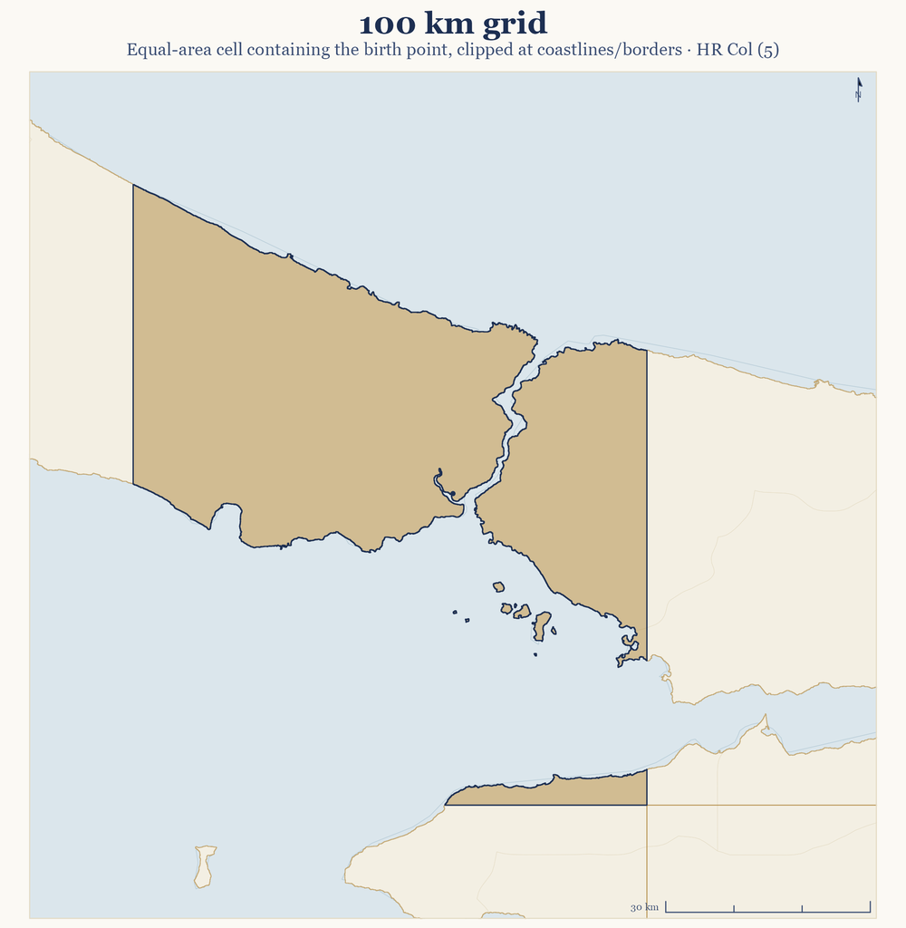

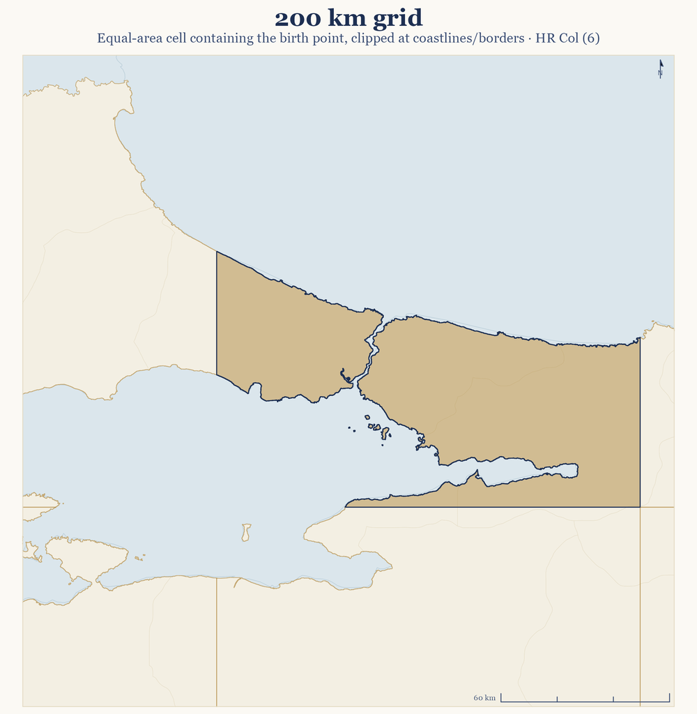

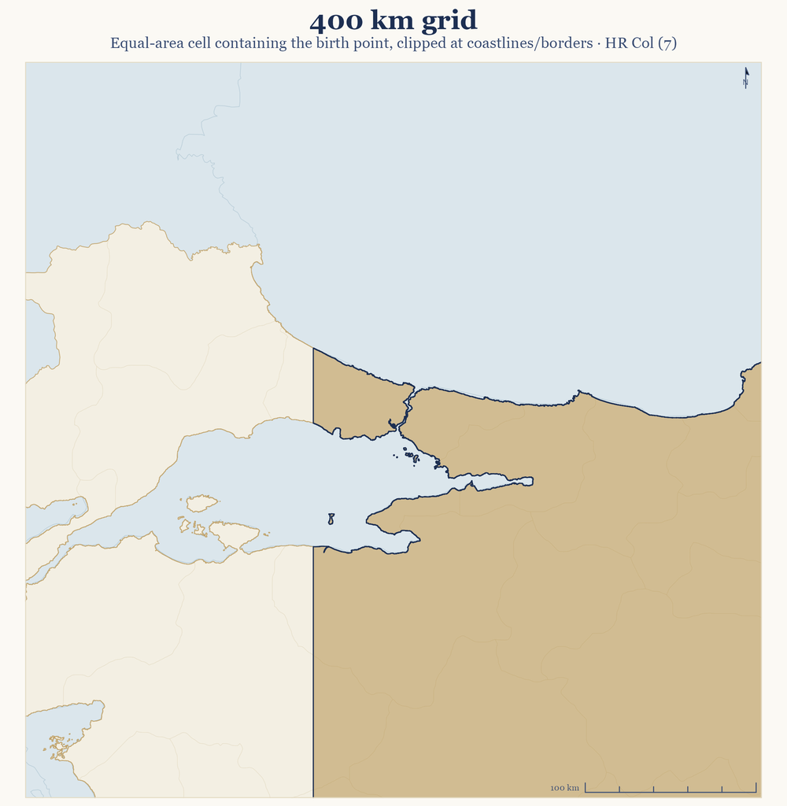

Sample restricted to HR’s exact **126-country, 1992-2009** window. Each column changes only the **size and shape of the spatial unit**, not the specification: from a tight 5 km circle around the leader’s birthplace, to the full home region, to the home region with the birth district cut out, to a world grid at four coarsening resolutions. The **Leader coefficient shrinks toward zero as the unit gets larger** in both HR’s numbers and ours, the same pattern the paper reports: favoritism shows up most clearly close to the leader’s birthplace and fades out as the unit of observation grows past it.

# Extension

Section 06 / 07

## Extension: Beyond HR’s Original Window

1992–2023Time Period

Harmonized **DMSP**<sup>1</sup>**/VIIRS**<sup>2</sup> panel, Li et al. (Li et al., 2020): 30 arc-sec (∼1 km) WGS84 GeoTIFF, 0-63 DN scale, nearly double HR’s own 1992-2009 window. VIIRS (2012 onward) is the higher-resolution successor sensor to DMSP, natively 15 arc-sec (∼500 m), with no saturation over bright urban cores.

<sup>1</sup> EOG DMSP (Earth Observation Group, Payne Institute for Public Policy, Colorado School of Mines, 2013) · <sup>2</sup> EOG VIIRS (Earth Observation Group, Payne Institute for Public Policy, Colorado School of Mines, 2012)

GHS-POPPopulation · 1990–2020

Own pipeline (Schiavina et al., 2023): 3 arc-sec (∼100 m) WGS84 GeoTIFF rasters, zonal-summed to ADM2, linearly interpolated to annual values.

PLAD + WikidataLeader Data

Same source as the main replication (Bomprezzi et al., 2024; Wikidata, 2026), extended to the full window.

## Extension: Results Over the Full 1992-2023 Window

|  | (1)Light<sub>ict</sub> | (2)Light<sub>ict</sub> | (3)Light<sub>ict</sub> | (4)Light<sub>ict</sub> | (5)Light<sub>ict</sub> | (6)Light0<sub>ict</sub> | (7)Lightpc<sub>ict</sub> |
| --- | --- | --- | --- | --- | --- | --- | --- |
| Leader<sub>ict-1</sub> | 0.048*** (0.017) |  |  | 0.025** (0.010) | 0.074*** (0.016) | 0.035** (0.016) | 0.026*** (0.009) |
| Leader<sub>ict</sub> |  | 0.043** (0.017) |  |  |  |  |  |
| Leader<sub>ict-2</sub> |  |  | 0.046** (0.018) |  |  |  |  |
| Light<sub>ict-1</sub> |  |  |  | 0.556*** (0.026) | 0.943*** (0.009) |  |  |
| Pop<sub>ict</sub> |  |  |  |  |  |  | -0.534*** (0.058) |
| Number of regions | 45,463 | 45,463 | 45,463 | 45,463 | 45,463 | 45,133 | 45,386 |
| Observations | 1,301,050 | 1,360,509 | 1,274,892 | 1,260,294 | 1,260,314 | 1,186,109 | 1,298,598 |
| Within R<sup>2</sup> | 0.516 | 0.461 | 0.435 | 0.634 | 0.945 | 0.604 | 0.472 |
| Region FE | Yes | Yes | Yes | Yes | No | Yes | Yes |
| Country-year FE | Yes | Yes | Yes | Yes | Yes | Yes | Yes |

The core result **holds up over the extended 1992-2023 window**, using entirely our own extension-era data pipeline: the Leader coefficient is positive and significant across every specification, contemporaneous (Col 2), two-year lag (Col 3), and the dynamic panel (Col 4). Column (6), the extensive margin, is the one column that **failed to replicate** on HR’s own 1992-2009 window; here it **recovers to significance**, consistent with a DMSP sensor floor rather than a fragile finding. Column (7) per capita is the most stable result in the table: 0.026, almost unchanged from 0.025 on the shorter window, despite an entirely different population source and estimation period.

# Conclusion

Section 07 / 07

## Conclusion

### The extension confirms it, not just once

# References

Alesina, A., Devleeschauwer, A., Easterly, W., Kurlat, S., & Wacziarg, R. (2003). Fractionalization. *Journal of Economic Growth*, *8*(2), 155–194. https://doi.org/10.1023/A:1024471506938

Alesina, A., & Giuliano, P. (2014). Family ties. *Handbook of Economic Growth*, 177–215. https://doi.org/10.1016/B978-0-444-53538-2.00004-6

Barro, R. J., & Lee, J.-W. (2013). *A new data set of educational attainment in the world, 1950–2010* (NBER Working Paper No. 15902). National Bureau of Economic Research. https://doi.org/10.3386/w15902

Bomprezzi, P., Dreher, A., Fuchs, A., Hailer, T., Kammerlander, A., Kaplan, L., Marchesi, S., Masi, T., Robert, C., & Unfried, K. (2024). *Wedded to prosperity? Informal influence and regional favoritism* (CEPR Discussion Paper No. 18878). Centre for Economic Policy Research. https://plad.uni-goettingen.de/data/

Bora, R. (2025). *Birthplace favoritism revisited: Replication, modern evidence, and crisis dynamics* (Discussion Paper No. 671). University of Queensland, School of Economics.

CIESIN, Columbia University. (2005). *Global subnational administrative boundaries (GPWv3 SUBADBND)*. https://sedac.ciesin.columbia.edu

CIESIN, Columbia University. (2018). *Gridded population of the world, version 4, revision 11 (GPWv4)*. https://sedac.ciesin.columbia.edu/data/collection/gpw-v4

CIESIN, Columbia University and CIAT. (2005). *Gridded population of the world, version 3 (GPWv3)*. https://sedac.ciesin.columbia.edu/data/collection/gpw-v3

Düben, C., Hodler, R., & Raschky, P. (2026). *Regional favoritism: New data, larger sample, same pattern* (CEPR Discussion Paper No. DP21239). Centre for Economic Policy Research.

Earth Observation Group, Payne Institute for Public Policy, Colorado School of Mines. (2012). *VIIRS nighttime lights*. https://eogdata.mines.edu/products/vnl/

Earth Observation Group, Payne Institute for Public Policy, Colorado School of Mines. (2013). *DMSP nighttime lights*. https://eogdata.mines.edu/products/dmsp/

Franck, R., & Rainer, I. (2012). Does the leader’s ethnicity matter? Ethnic favoritism, education, and health in sub-saharan africa. *American Political Science Review*, *106*(2), 294–325. https://doi.org/10.1017/S0003055412000172

GADM. (2018). *Database of global administrative areas, version 3.6*. https://gadm.org

Gennaioli, N., La Porta, R., Lopez-de-Silanes, F., & Shleifer, A. (2014). Growth in regions. *Journal of Economic Growth*, *19*(3), 259–309. https://doi.org/10.1007/s10887-014-9105-9

Goemans, H. E., Gleditsch, K. S., & Chiozza, G. (2009). Introducing archigos: A dataset of political leaders. *Journal of Peace Research*, *46*(2), 269–283. https://doi.org/10.1177/0022343308100719

Golden, M., & Min, B. (2013). Distributive politics around the world. *Annual Review of Political Science*, *16*, 73–99. https://doi.org/10.1146/annurev-polisci-052209-121553

Henderson, J. V., Storeygard, A., & Weil, D. N. (2012). Measuring economic growth from outer space. *American Economic Review*, *102*(2), 994–1028. https://doi.org/10.1257/aer.102.2.994

Heston, A., Summers, R., & Aten, B. (2012). *Penn world table version 7.1*. Center for International Comparisons of Production, Income; Prices, University of Pennsylvania.

Hodler, R., & Raschky, P. A. (2014). Regional favoritism. *The Quarterly Journal of Economics*, *129*(2), 995–1033. https://doi.org/10.1093/qje/qju004

Li, X., & Zhou, Y. (2017). A stepwise calibration of global DMSP/OLS stable nighttime light data (1992–2013). *Remote Sensing*, *9*(6), 637. https://doi.org/10.3390/rs9060637

Li, X., Zhou, Y., Zhao, M., & Zhao, X. (2020). *Harmonization of DMSP and VIIRS nighttime light data from 1992–2024 at the global scale*. figshare. https://doi.org/10.6084/m9.figshare.9828827

Marshall, M. G., Jaggers, K., & Gurr, T. R. (2010). Polity IV project: Political regime characteristics and transitions, 1800–2010. *Center for Systemic Peace*.

Nordhaus, W. D., Chen, X., & Rosen, R. (2006). *G-econ 4.0: Geographically based economic data*. https://gecon.yale.edu

OECD. (2013). *International development statistics: Net official development assistance*. https://www.oecd.org/dac/stats

Schiavina, M., Freire, S., & MacManus, K. (2023). *GHS-POP R2023A – GHS population grid multitemporal (1975–2030)*. European Commission, Joint Research Centre (JRC). https://doi.org/10.2905/2FF68A52-5B5B-4A22-8F40-C41DA8332CFE

Wikidata. (2026). *Political leader birthplace supplement (own wikidata/wikipedia scrape)*. https://www.wikidata.org

World Bank. (2013). *Adjusted net savings, oil rents component*. https://data.worldbank.org

## Thank You

Questions?

[interactive chart not shown]